# Лабораторная работа №4

Операционные системы

Панина Ж. В.

Российский университет дружбы народов, Москва, Россия

14 марта 2025

# Информация

## Докладчик

- Панина Жанна Валерьевна
- НКАбд-02-24, студ. билет № 1132246710
- студент направления “Компьютерные и информационные науки”
- Российский университет дружбы народов
- 1132246710@pfur.ru
- https://github.com/zvpanina/study_2024-2025_os-intro

# Вводная часть

## Актуальность

В современном мире безопасность данных играет ключевую роль, особенно при хранении и управлении паролями. Утилиты pass, gopass, native messaging и chezmoi позволяют безопасно управлять конфиденциальной информацией, автоматизировать процесс конфигурирования и синхронизировать данные с системами контроля версий. Изучение этих инструментов актуально для повышения уровня кибербезопасности и оптимизации рабочего процесса.

## Объект и предмет исследования

### Объект исследования:

Методы управления паролями и конфигурационными файлами в операционных системах на базе Linux.

### Предмет исследования:

Утилиты pass, gopass, native messaging, chezmoi и их интеграция с системой контроля версий git.

## Цели и задачи

Цель работы - познакомиться с pass, gopass, native messaging, chezmoi. Научиться пользоваться этими утилитами, синхронизировать их с git.

### Задачи:

1. Установить дополнительное ПО
2. Установить и настроить pass
3. Настроить интерфейс с браузером
4. Сохранить пароль
5. Установить и настроить chezmoi
6. Настроить chezmoi на новой машине
7. Выполнить ежедневные операции с chezmoi

## Материалы и методы

Используемое программное обеспечение: Fedora, VirtualBox, утилиты pass, gopass, chezmoi, git. Методы исследования: изучение документации, практическое тестирование утилит, настройка синхронизации с git, анализ работы инструментов и их взаимодействия.

# Теоретическое введение

Менеджер паролей pass — программа, сделанная в рамках идеологии Unix. Также носит название стандартного менеджера паролей для Unix (The standard Unix password manager). * Основные свойства Данные хранятся в файловой системе в виде каталогов и файлов. Файлы шифруются с помощью GPG-ключа. * Структура базы паролей Структура базы может быть произвольной, если Вы собираетесь использовать её напрямую, без промежуточного программного обеспечения. Тогда семантику структуры базы данных Вы держите в своей голове. Если же необходимо использовать дополнительное программное обеспечение, необходимо семантику заложить в структуру базы паролей. chezmoi используется для управления файлами конфигурации домашнего каталога пользователя. Конфигурация chezmoi - Рабочие файлы Состояние файлов конфигурации сохраняется в каталоге ~/.local/share/chezmoi. Он является клоном вашего репозитория dotfiles. Файл конфигурации ~/.config/chezmoi/chezmoi.toml (можно использовать также JSON или YAML) специфичен для локальной машины. Файлы, содержимое которых одинаково на всех ваших машинах, дословно копируются из исходного каталога. Файлы, которые варьируются от машины к машине, выполняются как шаблоны, обычно с использованием данных из файла конфигурации локальной машины для настройки конечного содержимого, специфичного для локальной машины.

# Выполнение лабораторной работы

## Менеджер паролей pass

### Установка

1. Выполняю установку pass.

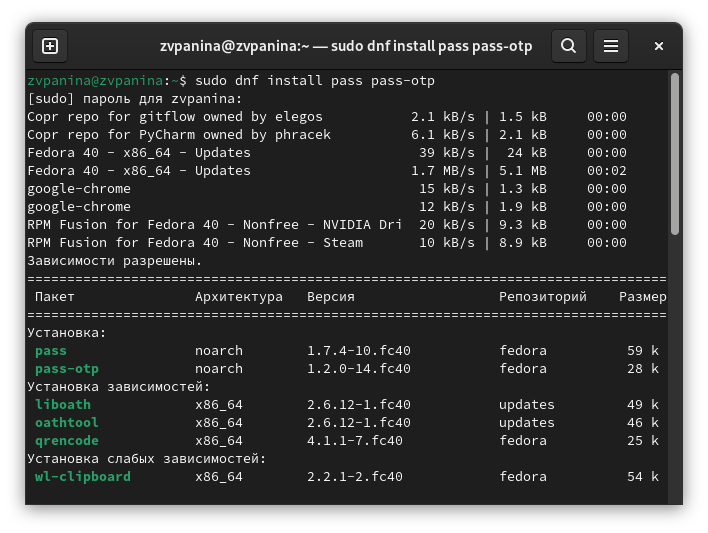

Установка pass

2. Выполняю установку gopass.

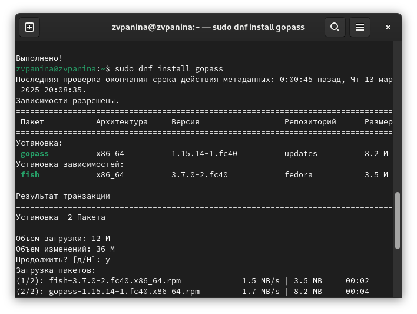

Установка gopass

### Настройка

1. Просматриваю список ключей GPG, инициализирую хранилище с помощью id ключа и создаю структуру git. Задам адрес репозитория git-extended (ранее созданного) на хостинге.

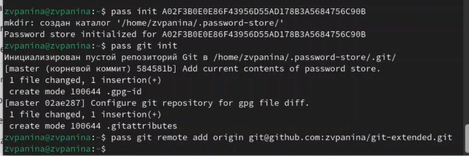

Инициализация хранилища и синхронизация с git

2. Для синхронизации выполняю следующие команды: pass git pull.

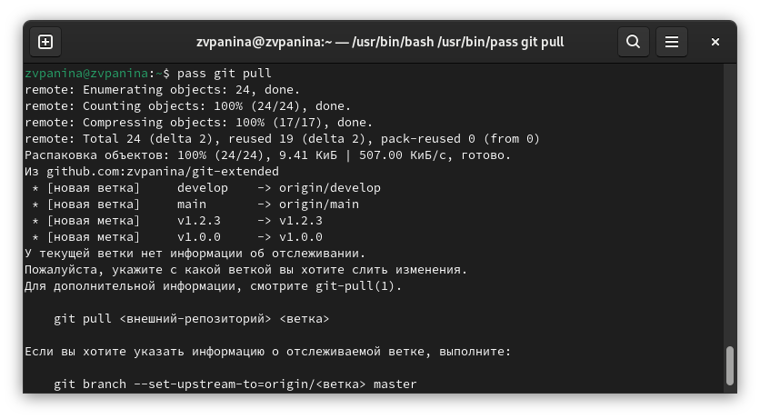

pass git pull

pass git push.

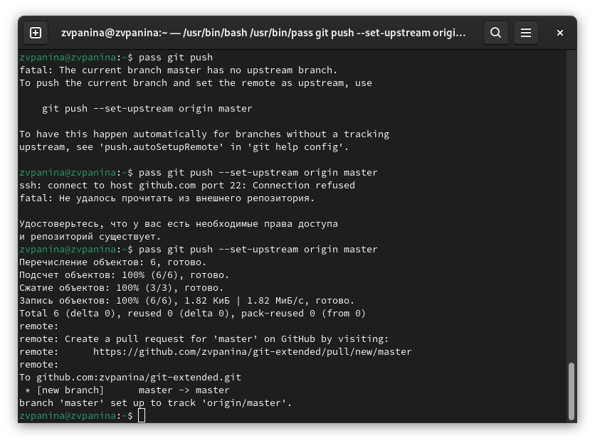

pass git push

3. Если изменения сделаны непосредственно на файловой системе, необходимо вручную закоммитить и выложить изменения. Проверяю статус синхронизации командой git status.

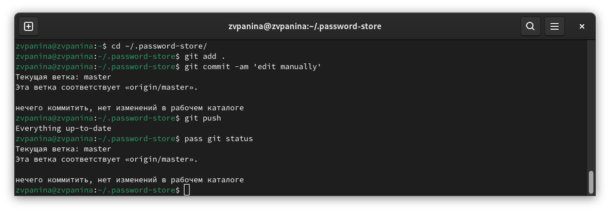

Прямые изменения

### Настройка интерфейса с браузером

1. Захожу в репозиторий browserpass-extension.

[figure not shown]

github browserpass-extension

2. Скачиваю плагин для браузера Firefox.

[figure not shown]

Плагин для Firefox

3. Подключаю интерфейс для взаимодействия с браузером.

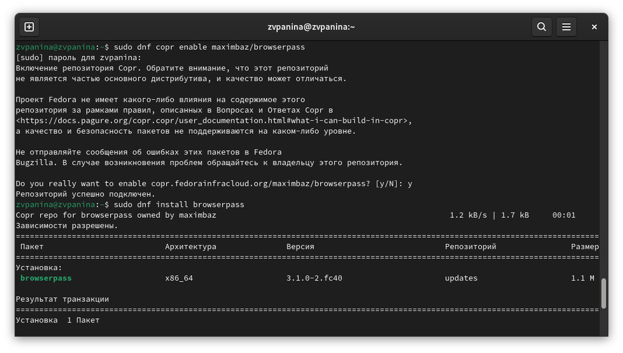

Интерфейс для взаимодействия с браузером

### Сохранение пароля

1. Добавляю новый пароль.

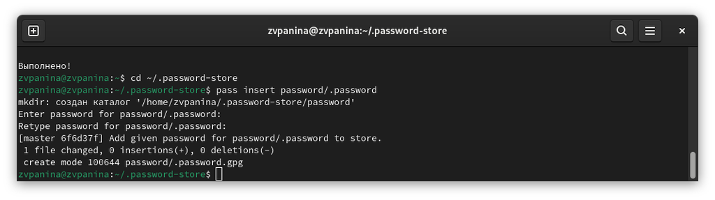

Добавление нового пароля

2. Отображаю пароль для указанного имени файла и заменяю существующий пароль.

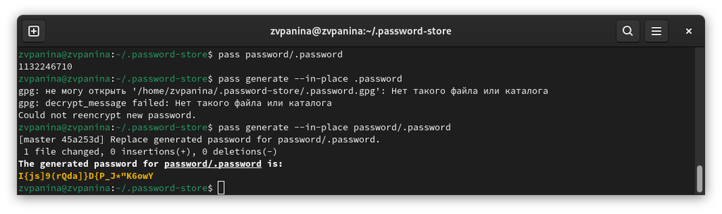

Отображение и замена пароля

## Управление файлами конфигурации

### Дополнительное программное обеспечение

1. Устанавливаю дополнительное программное обеспечение.

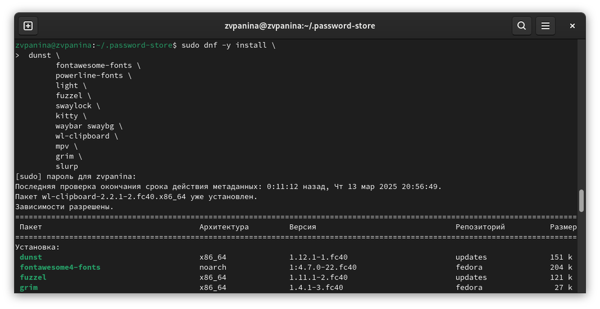

Установка дополнительного ПО

2. Устанавливаю шрифты.

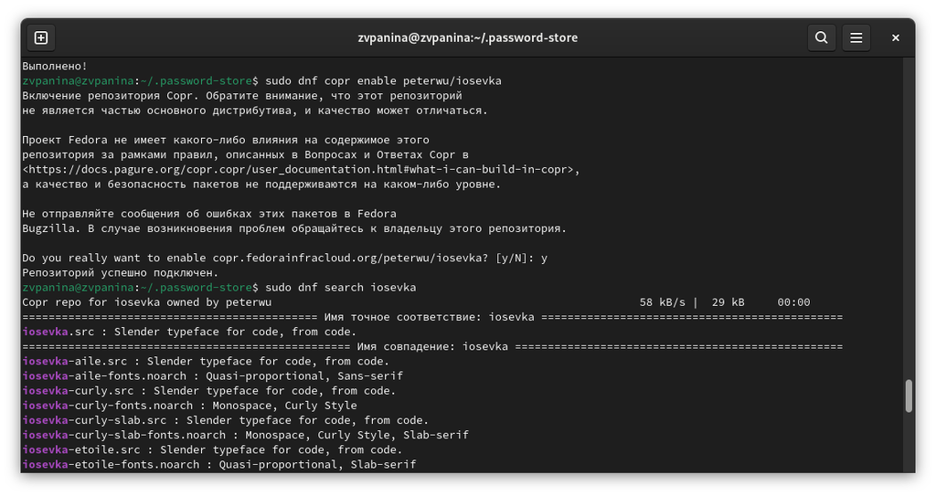

Установка шрифтов

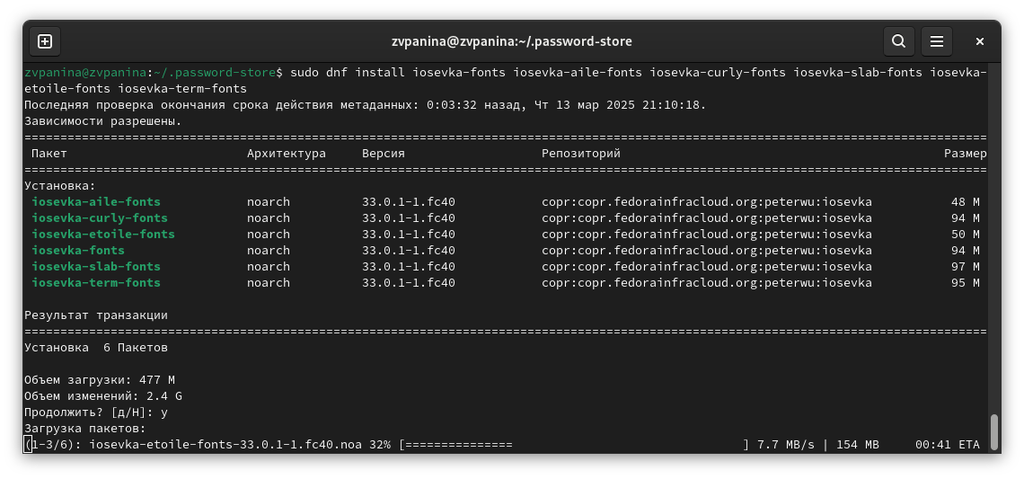

Установка шрифтов

3. Устанавливаю бинарный файл с помощью wget. Скрипт определяет архитектуру процессора и операционную систему и скачивает необходимый файл.

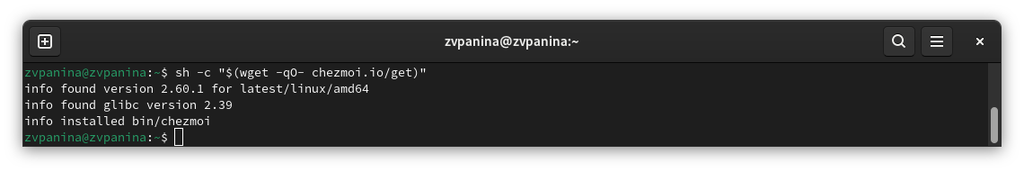

Установка бинарного файла

### Создание собственного репозитория с помощью утилит

Создаю свой репозиторий для конфигурационных файлов на основе шаблона.

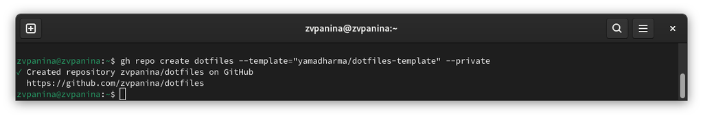

Создание репозитория

### Подключение репозитория к своей системе

1. Инициализирую chezmoi со своим репозиторием dotfiles.

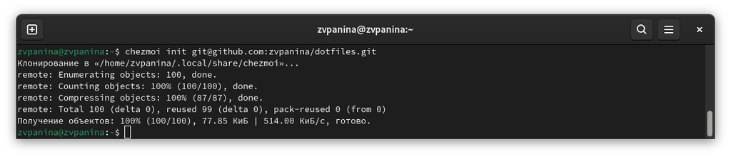

Инициализация chezmoi

2. Проверяю, какие изменения внесёт chezmoi в домашний каталог.

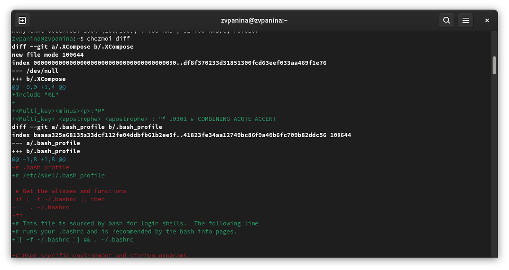

Проверка изменений

3. Изменения меня устраивают, поэтому применяю их.

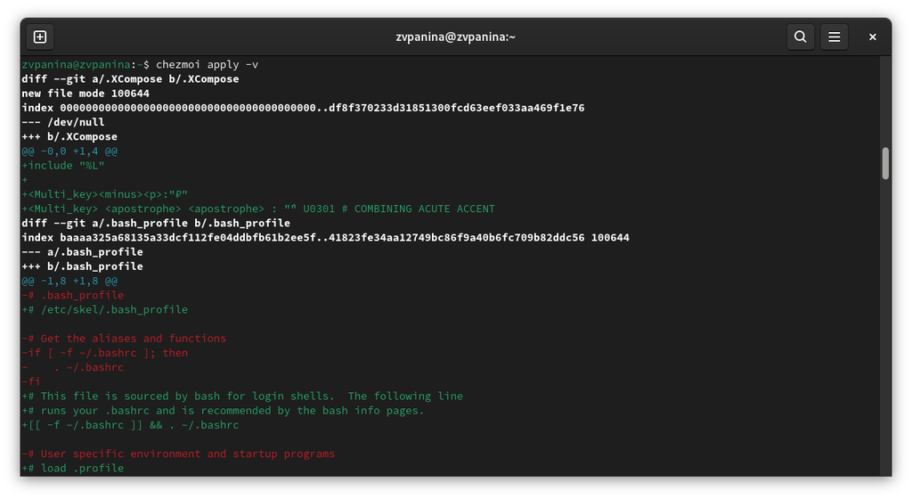

Применение изменений

### Использование chezmoi на нескольких машинах

На второй машине инициализирую chezmoi со своим репозиторием dotfiles.

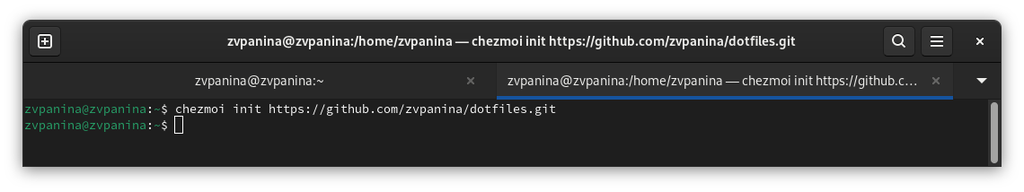

Инициализация chezmoi на второй машине

### Настройка новой машины с помощью одной команды

Устанавливаю свои dotfiles на новую машину с помощью одной команды.

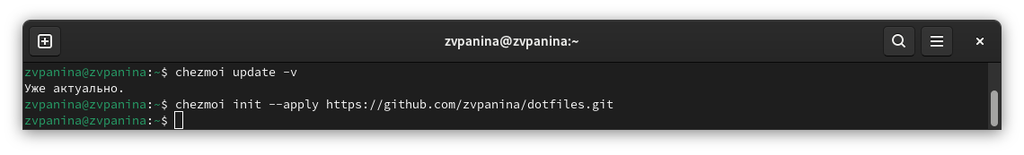

Установка dotfiles на новой машине

### Ежедневные операции с chezmoi

1. Первой командой извлекаю последние изменения из репозитория и применяю их. Второй командой извлекаю последние изменения из своего репозитория и смотрю, что изменится, фактически не применяя изменения. Ничего не изменилось. Применяю изменения.

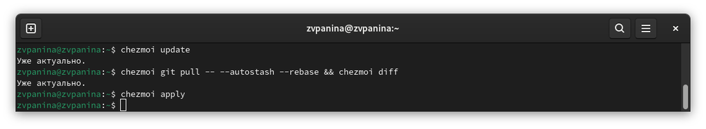

Извлечение изменений

2. Можно автоматически фиксировать и отправлять изменения в исходный каталог в репозиторий. Открываю в mc файл конфигурации ~/.config/chezmoi/chezmoi.toml и добавляю в него следующее.

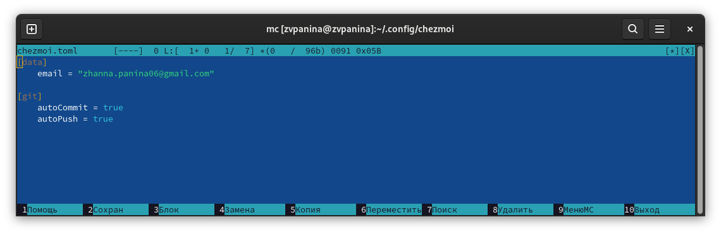

Корректировка конфигурационного файла

## Результаты

В ходе выполнения лабораторной работы я познакомилась с pass, gopass, native messaging, chezmoi. Научилась пользоваться этими утилитами, синхронизировать их с git.

# Список литературы

Настройка электронной среды. (электронный ресурс) URL: https://yamadharma.github.io/ru/teaching/os-intro/lab/lab-work-environment-setup/